# Course project Regression models

12/9/2018

# Summary

```r
knitr::opts_chunk$set(echo = TRUE, cache = TRUE)
```

```r
#Load the data set "mtcars"
data(mtcars)
summary(mtcars)
```

```
##       mpg             cyl             disp             hp
##  Min.   :10.40   Min.   :4.000   Min.   : 71.1   Min.   : 52.0
##  1st Qu.:15.43   1st Qu.:4.000   1st Qu.:120.8   1st Qu.: 96.5
##  Median :19.20   Median :6.000   Median :196.3   Median :123.0
##  Mean   :20.09   Mean   :6.188   Mean   :230.7   Mean   :146.7
##  3rd Qu.:22.80   3rd Qu.:8.000   3rd Qu.:326.0   3rd Qu.:180.0
##  Max.   :33.90   Max.   :8.000   Max.   :472.0   Max.   :335.0
##       drat             wt             qsec             vs
##  Min.   :2.760   Min.   :1.513   Min.   :14.50   Min.   :0.0000
##  1st Qu.:3.080   1st Qu.:2.581   1st Qu.:16.89   1st Qu.:0.0000
##  Median :3.695   Median :3.325   Median :17.71   Median :0.0000
##  Mean   :3.597   Mean   :3.217   Mean   :17.85   Mean   :0.4375
##  3rd Qu.:3.920   3rd Qu.:3.610   3rd Qu.:18.90   3rd Qu.:1.0000
##  Max.   :4.930   Max.   :5.424   Max.   :22.90   Max.   :1.0000
##        am              gear            carb
##  Min.   :0.0000   Min.   :3.000   Min.   :1.000
##  1st Qu.:0.0000   1st Qu.:3.000   1st Qu.:2.000
##  Median :0.0000   Median :4.000   Median :2.000
##  Mean   :0.4062   Mean   :3.688   Mean   :2.812
##  3rd Qu.:1.0000   3rd Qu.:4.000   3rd Qu.:4.000
##  Max.   :1.0000   Max.   :5.000   Max.   :8.000
```

```r
head(mtcars)
```

```
##                    mpg cyl disp  hp drat    wt  qsec vs am gear carb
## Mazda RX4         21.0   6  160 110 3.90 2.620 16.46  0  1    4    4
## Mazda RX4 Wag     21.0   6  160 110 3.90 2.875 17.02  0  1    4    4
## Datsun 710        22.8   4  108  93 3.85 2.320 18.61  1  1    4    1
## Hornet 4 Drive    21.4   6  258 110 3.08 3.215 19.44  1  0    3    1
## Hornet Sportabout 18.7   8  360 175 3.15 3.440 17.02  0  0    3    2
## Valiant           18.1   6  225 105 2.76 3.460 20.22  1  0    3    1
```

```r
#am variable 0 = automatic, 1 = manual
```

```r
#Preparing for the explatory analysis
library(dplyr)
```

```r
library(ggplot2)
```

# Data description

The data was extracted from the 1974 Motor Trend US magazine, and comprises fuel consumption and 10 aspects of automobile design and performance for 32 automobiles (1973–74 models). It is a data frame with 32 observations on 11 (numeric) variables.

- mpg: Miles/(US) gallon
- cyl: Number of cylinders
- disp: Displacement (cu.in.)
- hp: Gross horsepower
- drat: Rear axle ratio
- wt: Weight (1000 lbs)
- qsec: 1/4 mile time
- vs: Engine (0 = V-shaped, 1 = straight)
- am: Transmission (0 = automatic, 1 = manual)
- gear: Number of forward gears
- carb: Number of carburetors

# Prepearing for the analysis

Before we start the analysis, we need to change the classes of some variables.

```r
#change variable clasees
mtcars$cyl <- factor(mtcars$cyl)
mtcars$am <- factor(mtcars$am, levels = c(0,1), labels = c("automatic", "manual"))
mtcars$vs <- factor(mtcars$vs, levels = c(0,1), labels = c("V-shaped", "straight"))
mtcars$gear <- factor(mtcars$gear)
mtcars$carb <- factor(mtcars$carb)
str(mtcars)
```

```
## 'data.frame':    32 obs. of  11 variables:
##  $ mpg : num  21 21 22.8 21.4 18.7 18.1 14.3 24.4 22.8 19.2 ...
##  $ cyl : Factor w/ 3 levels "4","6","8": 2 2 1 2 3 2 3 1 1 2 ...
##  $ disp: num  160 160 108 258 360 ...
##  $ hp  : num  110 110 93 110 175 105 245 62 95 123 ...
##  $ drat: num  3.9 3.9 3.85 3.08 3.15 2.76 3.21 3.69 3.92 3.92 ...
##  $ wt  : num  2.62 2.88 2.32 3.21 3.44 ...
##  $ qsec: num  16.5 17 18.6 19.4 17 ...
##  $ vs  : Factor w/ 2 levels "V-shaped","straight": 1 1 2 2 1 2 1 2 2 2 ...
##  $ am  : Factor w/ 2 levels "automatic","manual": 2 2 2 1 1 1 1 1 1 1 ...
##  $ gear: Factor w/ 3 levels "3","4","5": 2 2 2 1 1 1 1 2 2 2 ...
##  $ carb: Factor w/ 6 levels "1","2","3","4",..: 4 4 1 1 2 1 4 2 2 4 ...
```

# First analysis (mpg vs am)

Firstly, we check only mpg and am variables. See Figure 1 in the appendix.

```r
#ttest
t.test(mtcars$mpg ~ mtcars$am, alternative = "two.sided", paired = FALSE, var.equal = FALSE)
```

```
##
##  Welch Two Sample t-test
##
## data:  mtcars$mpg by mtcars$am
## t = -3.7671, df = 18.332, p-value = 0.001374
## alternative hypothesis: true difference in means is not equal to 0
## 95 percent confidence interval:
##  -11.280194  -3.209684
## sample estimates:
## mean in group automatic    mean in group manual
##                17.14737                24.39231
```

It is quite obvious that the manual cars have heigher mean than the automatic ones, but we suspect other variables that afects this relationship.

# Explanation

Now we check the all possibles relationships in the variables. To do that, we use **pairs **function to investigate possible correlation between variables. As a result of the plot, cyl, disp, hp, drat, wt, vs, and am seem to have strong relationship with the mpg variable. See the Figure 2.****

# Modeling

## Linear model

```r
fit <- lm(mpg ~ am, data = mtcars)
summary(fit)
```

```
##
## Call:
## lm(formula = mpg ~ am, data = mtcars)
##
## Residuals:
##     Min      1Q  Median      3Q     Max
## -9.3923 -3.0923 -0.2974  3.2439  9.5077
##
## Coefficients:
##             Estimate Std. Error t value Pr(>|t|)
## (Intercept)   17.147      1.125  15.247 1.13e-15 ***
## ammanual       7.245      1.764   4.106 0.000285 ***
## ---
## Signif. codes:  0 '***' 0.001 '**' 0.01 '*' 0.05 '.' 0.1 ' ' 1
##
## Residual standard error: 4.902 on 30 degrees of freedom
## Multiple R-squared:  0.3598, Adjusted R-squared:  0.3385
## F-statistic: 16.86 on 1 and 30 DF,  p-value: 0.000285
```

## Residuals

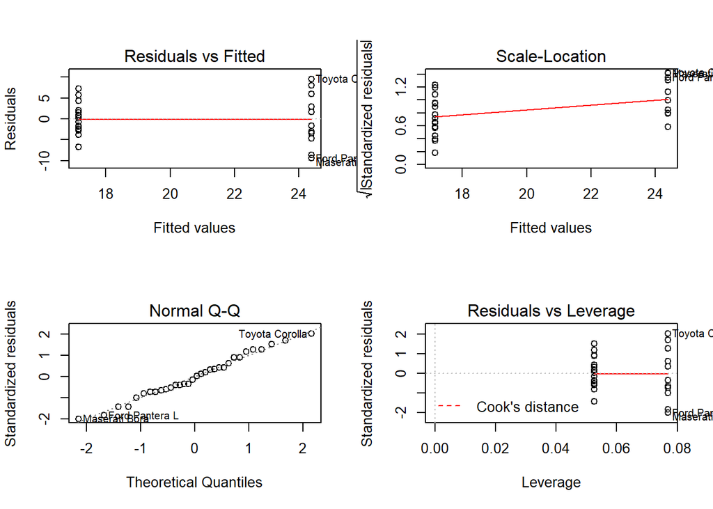

```r
par(mfcol = c(2,2))
plot(fit)
```

## Modeling test

As we see in Figure 2, there are some strong relationships between mpg and some variables of the data set. We have to check if these variables are statistically significant in the regression. In order to obtain the optimal regression, we conduct AIC algorithms. First, we take all dependent variables and then elminate on eby one until AIC score reaches a limit.

```r
initial_fit <- lm(mpg ~ ., data = mtcars)
final_fit <- step(initial_fit, direction = "both")
```

```
## Start:  AIC=76.4
## mpg ~ cyl + disp + hp + drat + wt + qsec + vs + am + gear + carb
##
##        Df Sum of Sq    RSS    AIC
## - carb  5   13.5989 134.00 69.828
## - gear  2    3.9729 124.38 73.442
## - am    1    1.1420 121.55 74.705
## - qsec  1    1.2413 121.64 74.732
## - drat  1    1.8208 122.22 74.884
## - cyl   2   10.9314 131.33 75.184
## - vs    1    3.6299 124.03 75.354
## <none>              120.40 76.403
## - disp  1    9.9672 130.37 76.948
## - wt    1   25.5541 145.96 80.562
## - hp    1   25.6715 146.07 80.588
##
## Step:  AIC=69.83
## mpg ~ cyl + disp + hp + drat + wt + qsec + vs + am + gear
##
##        Df Sum of Sq    RSS    AIC
## - gear  2    5.0215 139.02 67.005
## - disp  1    0.9934 135.00 68.064
## - drat  1    1.1854 135.19 68.110
## - vs    1    3.6763 137.68 68.694
## - cyl   2   12.5642 146.57 68.696
## - qsec  1    5.2634 139.26 69.061
## <none>              134.00 69.828
## - am    1   11.9255 145.93 70.556
## - wt    1   19.7963 153.80 72.237
## - hp    1   22.7935 156.79 72.855
## + carb  5   13.5989 120.40 76.403
##
## Step:  AIC=67
## mpg ~ cyl + disp + hp + drat + wt + qsec + vs + am
##
##        Df Sum of Sq    RSS    AIC
## - drat  1    0.9672 139.99 65.227
## - cyl   2   10.4247 149.45 65.319
## - disp  1    1.5483 140.57 65.359
## - vs    1    2.1829 141.21 65.503
```

[output cut: 56 more lines]

```
## Step:  AIC=61.65
## mpg ~ cyl + hp + wt + am
##
##        Df Sum of Sq    RSS    AIC
## <none>              151.03 61.655
## - am    1     9.752 160.78 61.657
## + vs    1     7.346 143.68 62.059
## + qsec  1     7.044 143.98 62.126
## - cyl   2    29.265 180.29 63.323
## + disp  1     0.617 150.41 63.524
## + drat  1     0.220 150.81 63.608
## + gear  2     1.361 149.66 65.365
## - hp    1    31.943 182.97 65.794
## - wt    1    46.173 197.20 68.191
## + carb  5     5.633 145.39 70.438
```

And this regression seems to be better than the regression with only am variable.

```r
anova(fit,final_fit)
```

```
## Analysis of Variance Table
##
## Model 1: mpg ~ am
## Model 2: mpg ~ cyl + hp + wt + am
##   Res.Df    RSS Df Sum of Sq      F    Pr(>F)
## 1     30 720.90
## 2     26 151.03  4    569.87 24.527 1.688e-08 ***
## ---
## Signif. codes:  0 '***' 0.001 '**' 0.01 '*' 0.05 '.' 0.1 ' ' 1
```

## Analysis of final_fit

### residual

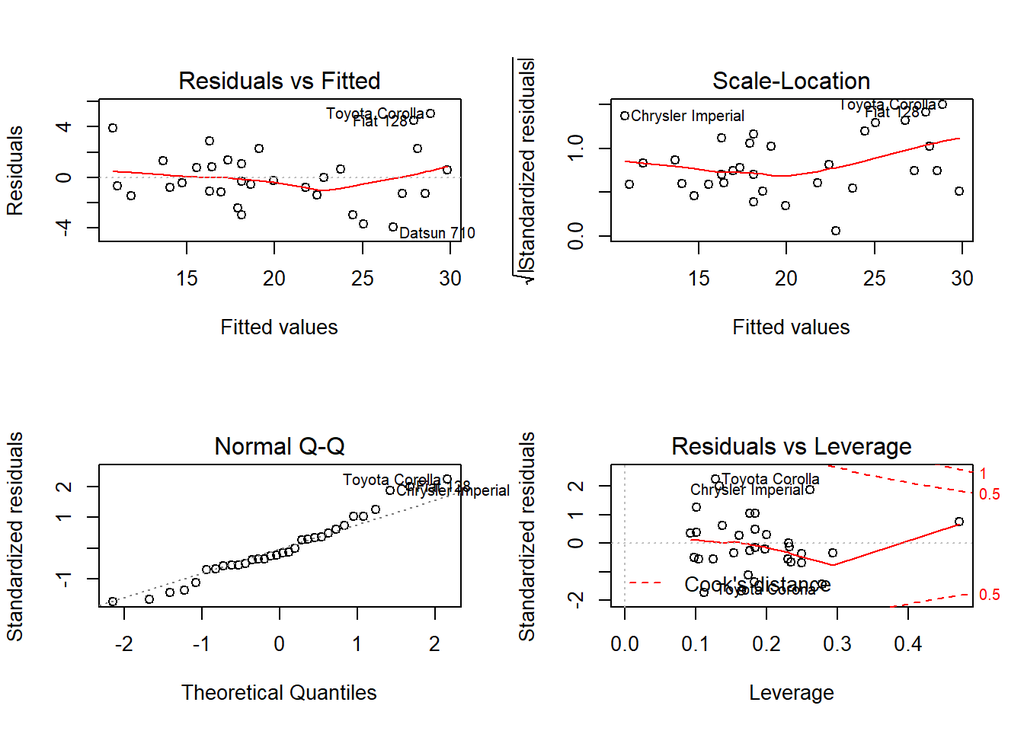

```r
par(mfcol = c(2,2))
plot(final_fit)
```

### final fit

```r
summary(final_fit)
```

```
##
## Call:
## lm(formula = mpg ~ cyl + hp + wt + am, data = mtcars)
##
## Residuals:
##     Min      1Q  Median      3Q     Max
## -3.9387 -1.2560 -0.4013  1.1253  5.0513
##
## Coefficients:
##             Estimate Std. Error t value Pr(>|t|)
## (Intercept) 33.70832    2.60489  12.940 7.73e-13 ***
## cyl6        -3.03134    1.40728  -2.154  0.04068 *
## cyl8        -2.16368    2.28425  -0.947  0.35225
## hp          -0.03211    0.01369  -2.345  0.02693 *
## wt          -2.49683    0.88559  -2.819  0.00908 **
## ammanual     1.80921    1.39630   1.296  0.20646
## ---
## Signif. codes:  0 '***' 0.001 '**' 0.01 '*' 0.05 '.' 0.1 ' ' 1
##
## Residual standard error: 2.41 on 26 degrees of freedom
## Multiple R-squared:  0.8659, Adjusted R-squared:  0.8401
## F-statistic: 33.57 on 5 and 26 DF,  p-value: 1.506e-10
```

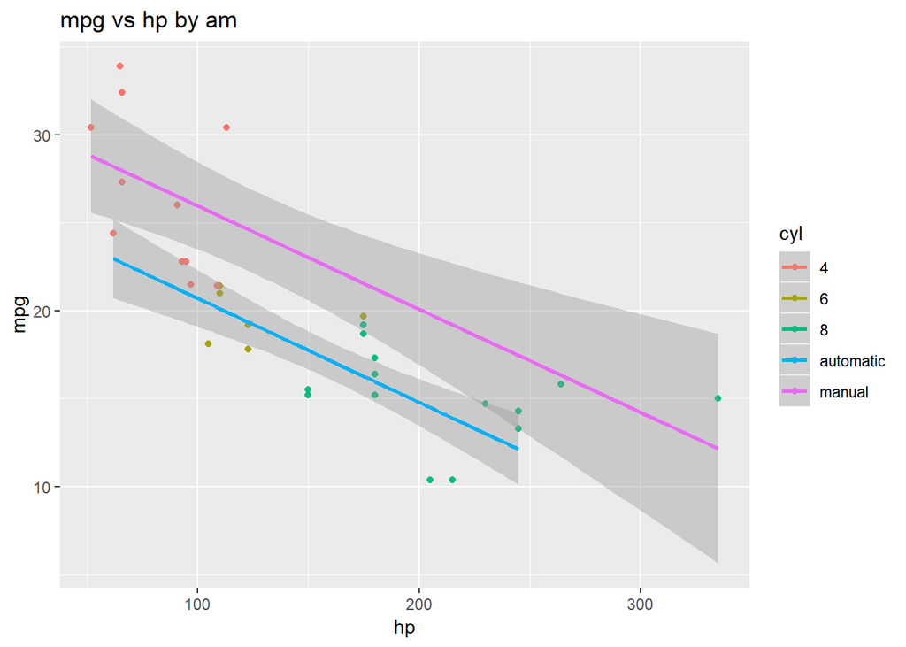

```r
#cyl hp wt am

mpg_hp <- ggplot(mtcars,aes(x = hp, y = mpg)) +
  geom_point(aes(color = cyl)) +
    geom_smooth(method = "lm", aes(color = am)) +
  ggtitle("mpg vs hp by am")
mpg_hp
```

```r
fit3 <- lm(mpg ~ hp*am, data = mtcars)
summary(fit3)
```

```
##
## Call:
## lm(formula = mpg ~ hp * am, data = mtcars)
##
## Residuals:
##     Min      1Q  Median      3Q     Max
## -4.3818 -2.2696  0.1344  1.7058  5.8752
##
## Coefficients:
##               Estimate Std. Error t value Pr(>|t|)
## (Intercept) 26.6248479  2.1829432  12.197 1.01e-12 ***
## hp          -0.0591370  0.0129449  -4.568 9.02e-05 ***
## ammanual     5.2176534  2.6650931   1.958   0.0603 .
## hp:ammanual  0.0004029  0.0164602   0.024   0.9806
## ---
## Signif. codes:  0 '***' 0.001 '**' 0.01 '*' 0.05 '.' 0.1 ' ' 1
##
## Residual standard error: 2.961 on 28 degrees of freedom
## Multiple R-squared:  0.782,  Adjusted R-squared:  0.7587
## F-statistic: 33.49 on 3 and 28 DF,  p-value: 2.112e-09
```

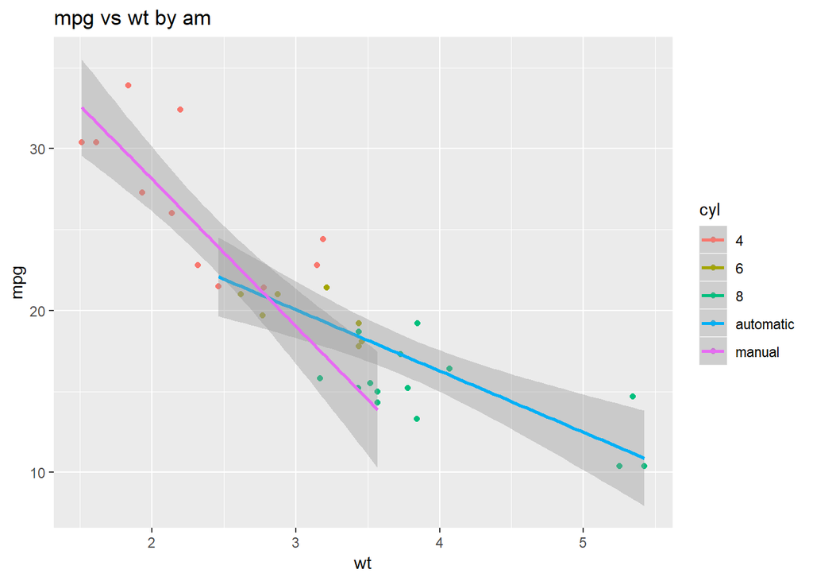

```r
mpg_wt <- ggplot(mtcars,aes(x = wt, y = mpg)) +
  geom_point(aes(color = cyl)) +
  geom_smooth(method = "lm", aes(color = am)) +
  ggtitle("mpg vs wt by am")
mpg_wt
```

```r
fit4 <- lm(mpg ~ wt*am, data = mtcars)
summary(fit4)
```

```
##
## Call:
## lm(formula = mpg ~ wt * am, data = mtcars)
##
## Residuals:
##     Min      1Q  Median      3Q     Max
## -3.6004 -1.5446 -0.5325  0.9012  6.0909
##
## Coefficients:
##             Estimate Std. Error t value Pr(>|t|)
## (Intercept)  31.4161     3.0201  10.402 4.00e-11 ***
## wt           -3.7859     0.7856  -4.819 4.55e-05 ***
## ammanual     14.8784     4.2640   3.489  0.00162 **
## wt:ammanual  -5.2984     1.4447  -3.667  0.00102 **
## ---
## Signif. codes:  0 '***' 0.001 '**' 0.01 '*' 0.05 '.' 0.1 ' ' 1
##
## Residual standard error: 2.591 on 28 degrees of freedom
## Multiple R-squared:  0.833,  Adjusted R-squared:  0.8151
## F-statistic: 46.57 on 3 and 28 DF,  p-value: 5.209e-11
```

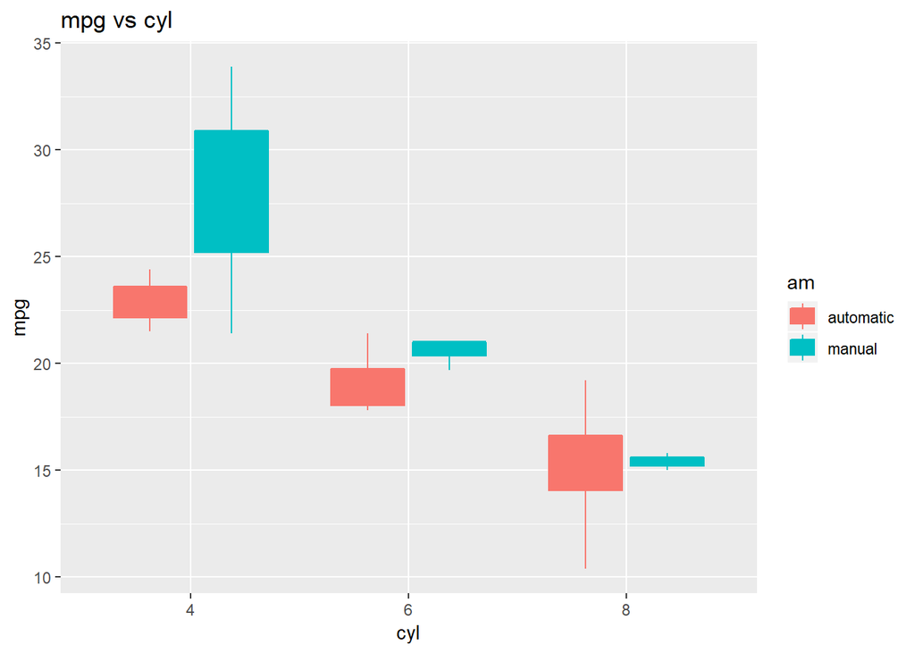

```r
mpg_cyl <- ggplot(mtcars,aes(x = cyl, y = mpg, fill = am)) +
  geom_boxplot(aes(color=am))  +
  ggtitle("mpg vs cyl")
mpg_cyl
```

```r
#4 cyl tends to have high mpg

fit5 <- lm(mpg ~ cyl*am, data = mtcars)
summary(fit5)
```

```
##
## Call:
## lm(formula = mpg ~ cyl * am, data = mtcars)
##
## Residuals:
##     Min      1Q  Median      3Q     Max
## -6.6750 -1.1000  0.1125  1.6875  5.8250
##
## Coefficients:
##               Estimate Std. Error t value Pr(>|t|)
## (Intercept)     22.900      1.751  13.081 6.06e-13 ***
## cyl6            -3.775      2.316  -1.630 0.115155
## cyl8            -7.850      1.957  -4.011 0.000455 ***
## ammanual         5.175      2.053   2.521 0.018176 *
## cyl6:ammanual   -3.733      3.095  -1.206 0.238553
## cyl8:ammanual   -4.825      3.095  -1.559 0.131069
## ---
## Signif. codes:  0 '***' 0.001 '**' 0.01 '*' 0.05 '.' 0.1 ' ' 1
##
## Residual standard error: 3.032 on 26 degrees of freedom
## Multiple R-squared:  0.7877, Adjusted R-squared:  0.7469
## F-statistic: 19.29 on 5 and 26 DF,  p-value: 5.179e-08
```

# Conclusion

To sum up, we conclude the following:

- First, munual transmission cars have more miles per galon (mpg) than automatic transmission cars. In concreatly?, the difference on the mean is 1.8 ajusted by cyl, hp and wt variables.
- secondly, with respect to the number of cylinders, the cylinder 4 seems to have the highest mean in both two transmission type. See boxplot

-thirdly, both hp and wt have negative relationship with mpg. If we increment hp or wt, mpg will decrease.

-Finally, we expect further explanation of this data set to predict mpg by other variables.

# Appendix

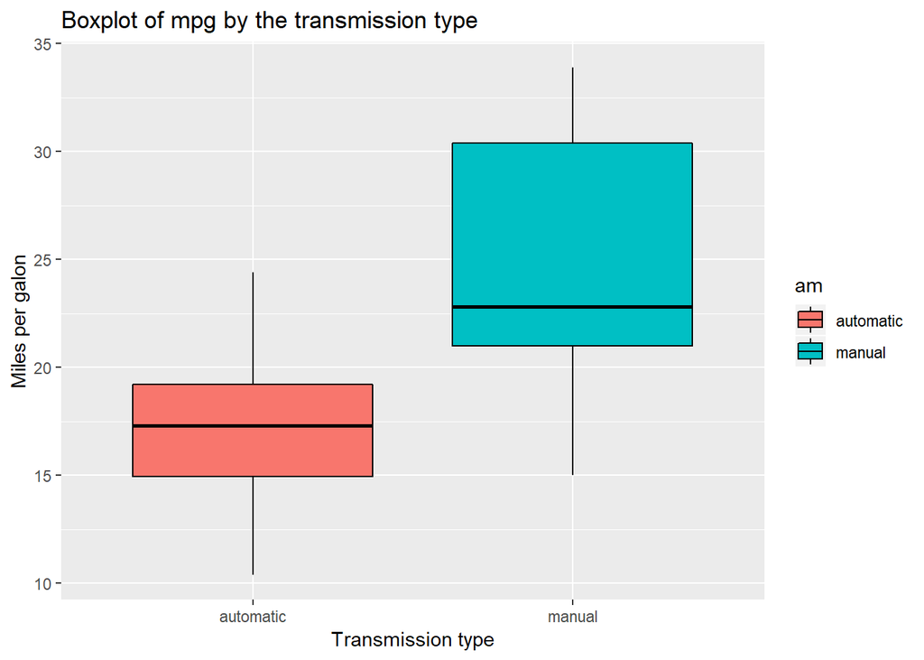

```r
#Figure 1
#Box plot
am_boxplot <- ggplot(mtcars,aes(y = mpg, x = am, fill = am)) +
  geom_boxplot(color = "black") +
  ggtitle("Boxplot of mpg by the transmission type") +
  xlab("Transmission type") +
  ylab("Miles per galon")
am_boxplot
```

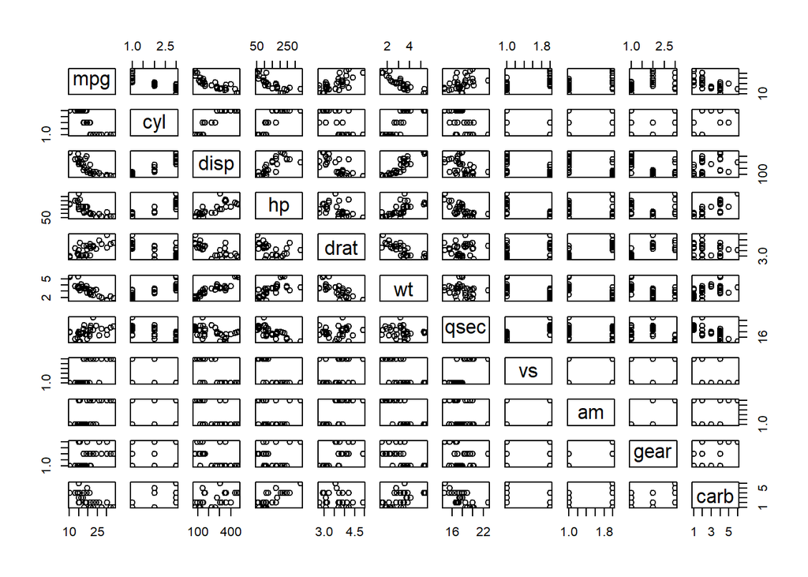

```r
#Figure2
#pairs plot
pairs(mpg ~ ., data = mtcars)
```

## disp

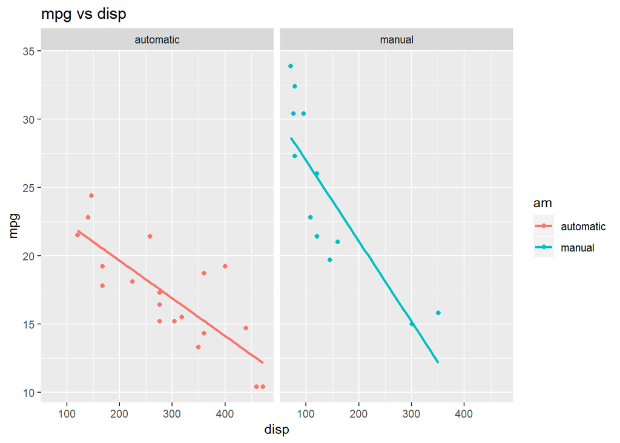

```r
#disp
mpg_disp <- ggplot(mtcars,aes(x = disp, y = mpg, fill = am)) +
  geom_point(aes(color = am)) +
  facet_wrap(~am, ncol = 2) +
  geom_smooth(method = "lm", aes(color = am), se = FALSE) +
  ggtitle("mpg vs disp")
mpg_disp
```

## hp

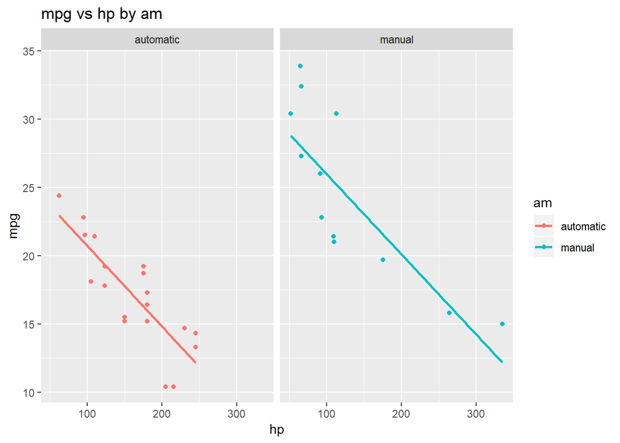

```r
mpg_hp <- ggplot(mtcars,aes(x = hp, y = mpg, fill = am)) +
  geom_point(aes(color = am)) +
  facet_wrap(~am, ncol = 2) +
  geom_smooth(method = "lm", aes(color = am), se = FALSE) +
  ggtitle("mpg vs hp by am")
mpg_hp
```

## drat

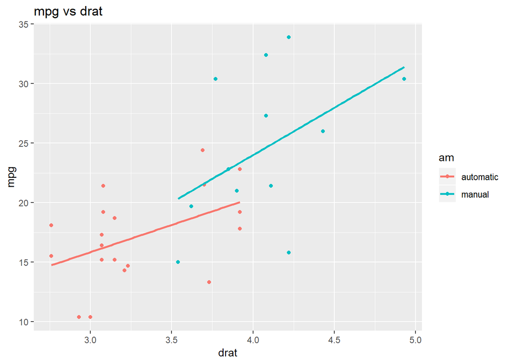

```r
mpg_drat <- ggplot(mtcars,aes(x = drat, y = mpg, fill = am)) +
  geom_point(aes(color = am)) +
  geom_smooth(method = "lm", aes(color = am), se = FALSE) +
  ggtitle("mpg vs drat")
mpg_drat
```

## wt

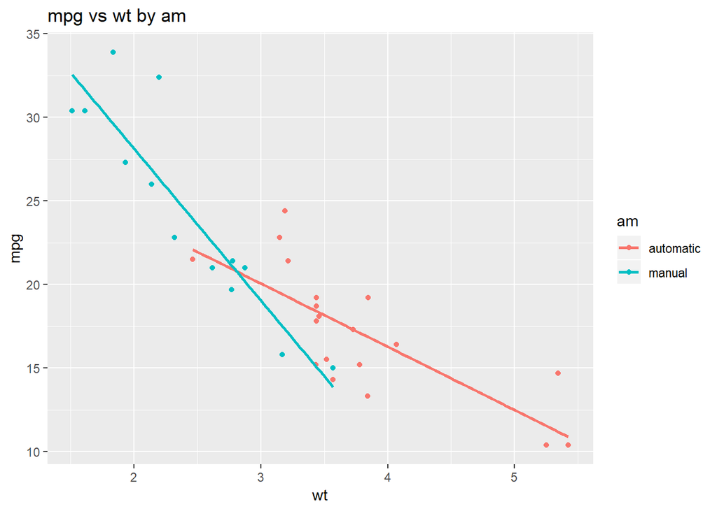

```r
mpg_wt <- ggplot(mtcars,aes(x = wt, y = mpg, fill = am)) +
  geom_point(aes(color = am)) +
  geom_smooth(method = "lm", aes(color = am), se = FALSE) +
  ggtitle("mpg vs wt by am")
mpg_wt
```

## vs Engine (0 = V-shaped, 1 = straight)

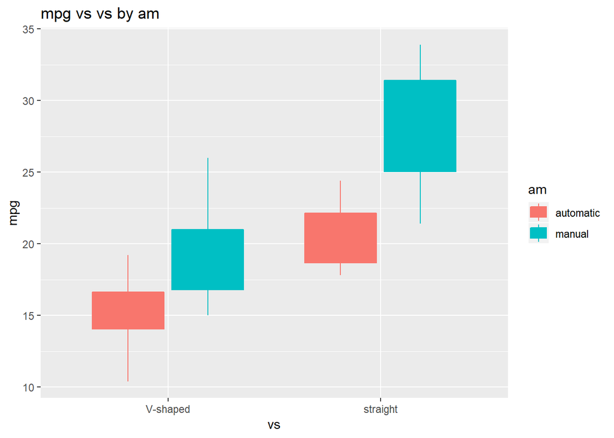

```r
mpg_vs <- ggplot(mtcars,aes(x = vs, y = mpg, fill = am)) +
  geom_boxplot(aes(color = am)) +
  ggtitle("mpg vs vs by am")
mpg_vs
```